# Bird Recognition

GitHub repo: https://github.com/UoA-eResearch/bird_recognition

## Load the necessary packages

```r
rm(list=ls(all=TRUE))
knitr::opts_chunk$set(echo=TRUE, message=FALSE, warning = FALSE)
knitr::opts_chunk$set(fig.width = 12, fig.height = 8, fig.align = 'center')
library(bioacoustics)
library(tuneR)
library(seewave)
library(dplyr)
library(tools)
library(ranger)
library(randomForest)
library(stringr)
#library(keras)
library(ggplot2)
library(caret)
```

## Load the wave files. Separate out the metadata from the filename into columns.

```r
files = list.files("wav_files_playback", "*.wav", full.names=TRUE)
files_without_extension = basename(file_path_sans_ext(files))
wavs = setNames(
  lapply(
    files,
    read_audio
  ),
  files_without_extension
)
metadata = data.frame(str_split_fixed(files_without_extension, "_", 3))
metadata = cbind(metadata, files_without_extension)
colnames(metadata) = c("birdid", "calltype", "idnumber", "filename")
```

## Split dataset into train / test since the sample size is small, the validation set won’t be used for now. The test dataset will contain one row for each combination of birdid / calltype

[output not shown]

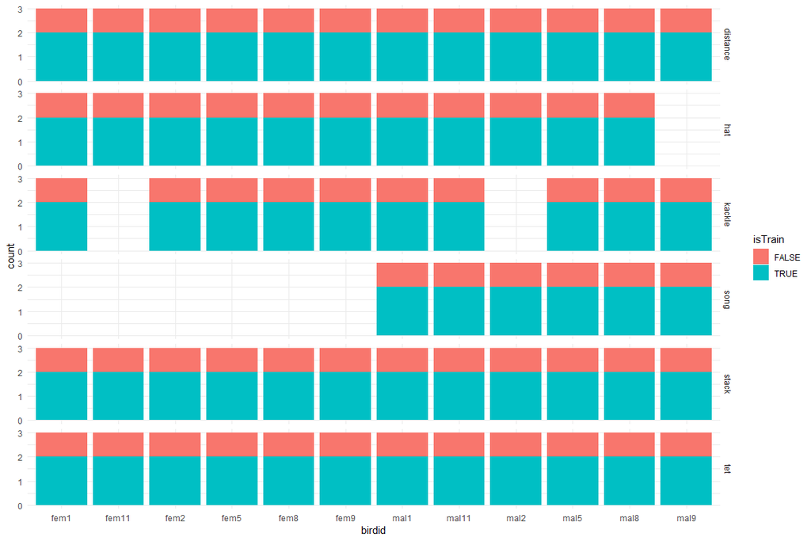

```r
metadata %>%
  group_by(birdid,calltype) %>%
  mutate(isTrain=row_number()!=test_row) %>%
  ungroup() %>%
  ggplot(aes(birdid,fill=isTrain)) +
    geom_bar(stat = "count") +
    facet_grid(calltype~.) +
    theme_minimal()
```

```r
mels = sapply(wavs, melfcc, numcep = 20) # Calculate all MFCCs
trainMels = mels[train$filename] # Select the MFCCs corresponding to the training dataset
testMels = mels[test$filename]
```

Audio recordings have different lengths

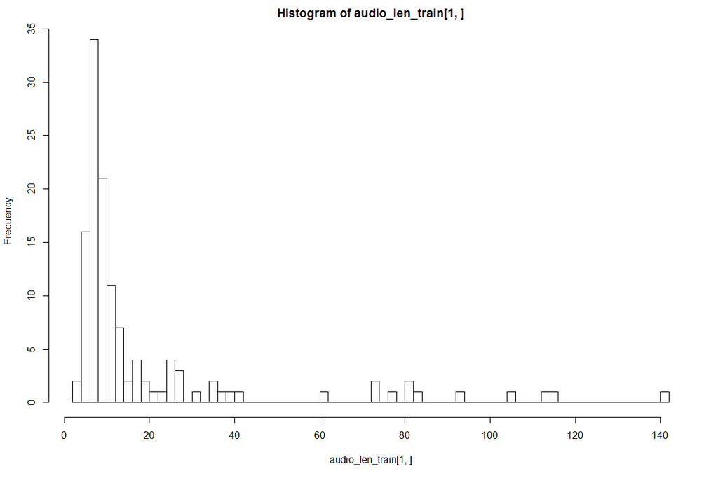

```r
audio_len_train = sapply(trainMels, dim)
audio_len_test = sapply(testMels,dim)
hist(audio_len_train[1,], breaks = 50)
```

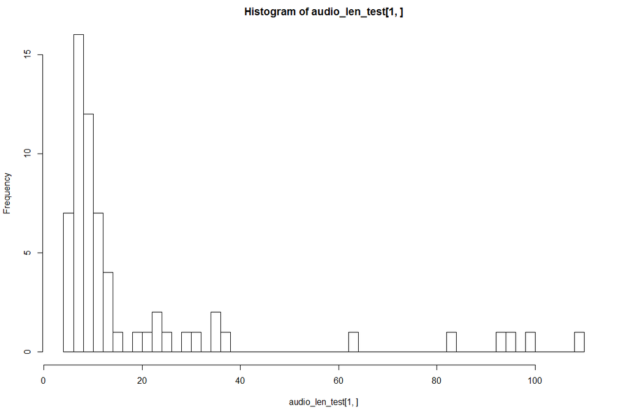

```r
hist(audio_len_test[1,], breaks = 50)
```

Since the audio lengths are different and most of them fall under 20 timesteps, the first 20 timesteps would be extracted. In addition, the number of MFCC coefficients is 20 so the data would have a nice (20,20) shape.

```r
timestepTake <- 20
# Only extract 20 first timesteps
extract20 <- function(matrixI) {
  test <- matrix(0,timestepTake,20)
  dimensionM <- dim(matrixI)
  timestepM <- min(timestepTake,dimensionM[1])
  test[1:timestepM, 1:dimensionM[2]] <- matrixI[1:timestepM, 1:dimensionM[2]]
  test
}
# Only taking the first 20 timesteps othwerwise zero
trainMels_20 <- lapply(trainMels, extract20)
testMels_20 <- lapply(testMels, extract20)
```

[figure not shown]

[figure not shown]

```r
# Flatten the matrices out
trainMels_20 <- matrix(unlist(trainMels_20), ncol=(20*20), byrow=TRUE)
testMels_20 <- matrix(unlist(testMels_20), ncol=(20*20), byrow=TRUE)
# Normalise
maxMels <- do.call(max,mels) # Calculate the max across the whole list of matrices to scale the predictor values between 0-1
trainMels_20 <- trainMels_20/maxMels
testMels_20 <- testMels_20/maxMels
```

## Using Random-Forest from `randomForest` package

```r
set.seed(138)
rf = randomForest(trainMels_20, train$birdid, xtest=testMels_20, ytest=test$birdid, importance = FALSE, proximity = FALSE, replace = TRUE, ntree = 1000, mtry = 20)
rf
```

```
Call:
 randomForest(x = trainMels_20, y = train$birdid, xtest = testMels_20,      ytest = test$birdid, ntree = 1000, mtry = 20, replace = TRUE,      importance = FALSE, proximity = FALSE)
               Type of random forest: classification
                     Number of trees: 1000
No. of variables tried at each split: 20

        OOB estimate of  error rate: 38.89%
Confusion matrix:
      fem1 fem11 fem2 fem5 fem8 fem9 mal1 mal11 mal2 mal5 mal8 mal9 class.error
fem1     9     0    0    1    0    0    0     0    0    0    0    0   0.1000000
fem11    0     7    0    0    0    0    0     0    0    0    0    1   0.1250000
fem2     0     0    6    0    0    2    0     0    0    0    1    1   0.4000000
fem5     1     0    1    7    1    0    0     0    0    0    0    0   0.3000000
fem8     0     0    0    0    7    1    2     0    0    0    0    0   0.3000000
fem9     0     0    1    0    2    7    0     0    0    0    0    0   0.3000000
mal1     0     0    1    0    2    1    5     3    0    0    0    0   0.5833333
mal11    0     0    0    0    0    0    2     8    0    1    0    1   0.3333333
mal2     0     1    0    0    1    1    1     0    6    0    0    0   0.4000000
mal5     0     0    3    1    0    0    0     0    0    7    1    0   0.4166667
mal8     2     0    0    0    1    1    1     1    2    0    4    0   0.6666667
mal9     0     1    0    0    0    0    1     0    2    2    0    4   0.6000000
                Test set error rate: 14.29%
Confusion matrix:
      fem1 fem11 fem2 fem5 fem8 fem9 mal1 mal11 mal2 mal5 mal8 mal9 class.error
fem1     3     0    0    0    1    0    0     0    0    1    0    0   0.4000000
fem11    0     3    0    0    0    0    0     0    0    0    0    1   0.2500000
fem2     0     0    5    0    0    0    0     0    0    0    0    0   0.0000000
fem5     1     0    0    4    0    0    0     0    0    0    0    0   0.2000000
fem8     0     0    0    0    5    0    0     0    0    0    0    0   0.0000000
fem9     0     0    0    0    0    5    0     0    0    0    0    0   0.0000000
mal1     0     0    0    0    0    1    5     0    0    0    0    0   0.1666667
mal11    0     0    0    0    1    0    0     5    0    0    0    0   0.1666667
mal2     0     0    0    0    0    1    0     0    3    1    0    0   0.4000000
mal5     0     0    0    0    0    0    0     0    0    6    0    0   0.0000000
mal8     0     0    0    0    0    0    0     0    0    0    6    0   0.0000000
mal9     0     0    0    0    0    0    0     1    0    0    0    4   0.2000000
```

```r
round(sum(diag(rf$test$confusion)) / sum(rf$test$confusion[,1:(ncol(rf$test$confusion) -1)]) * 100, 2)
```

```
[1] 85.71
```

Visualise wrong predictions

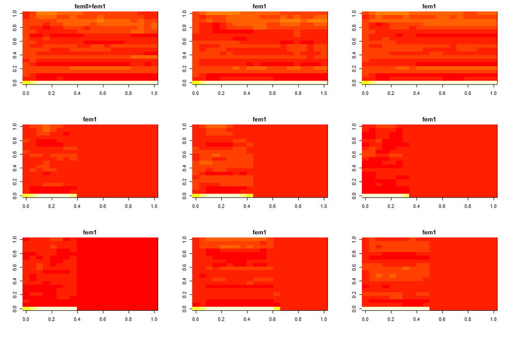

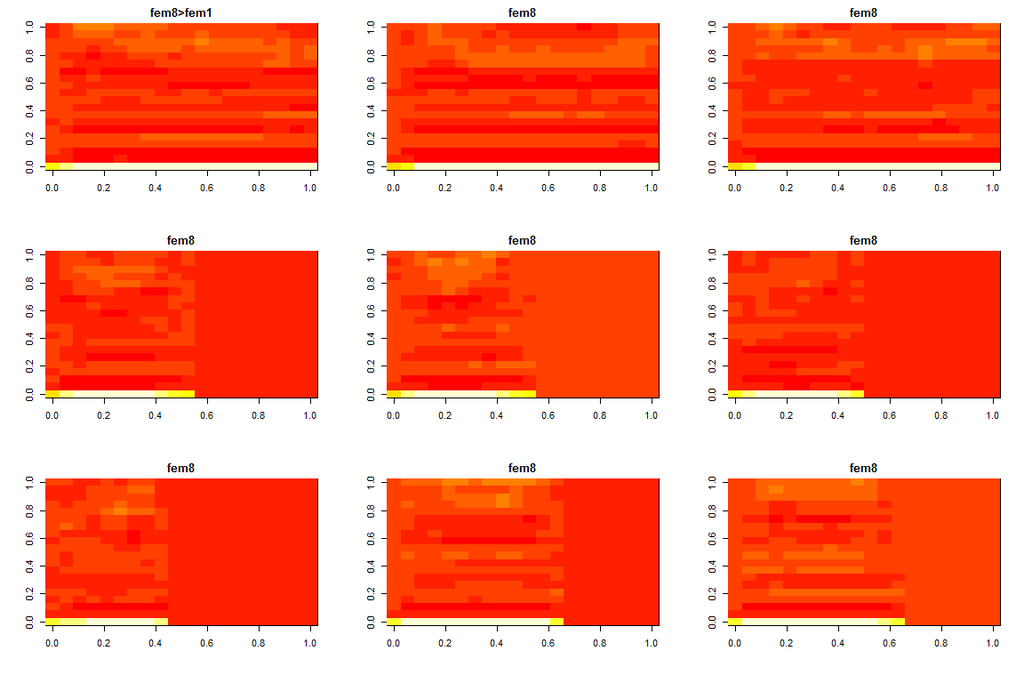

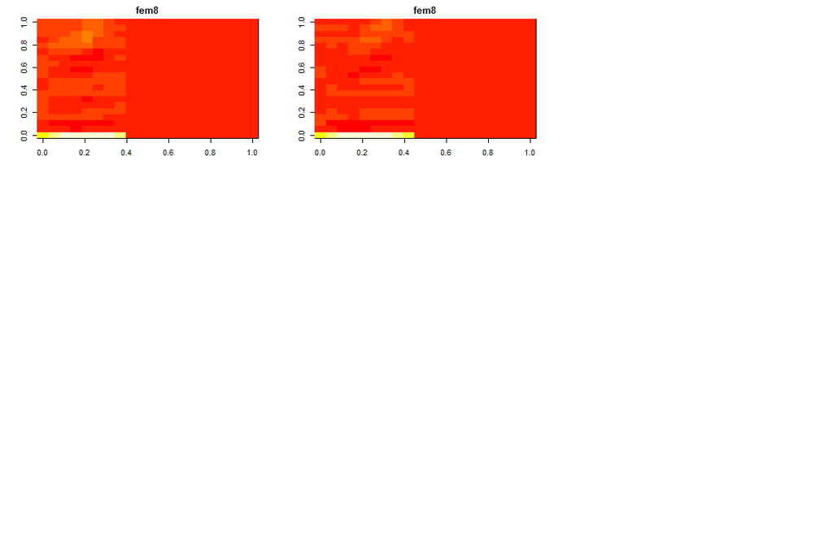

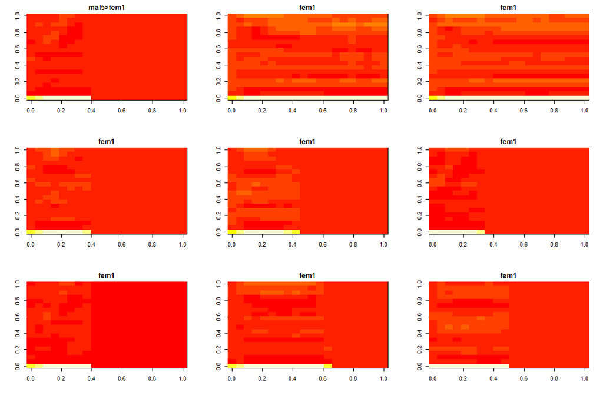

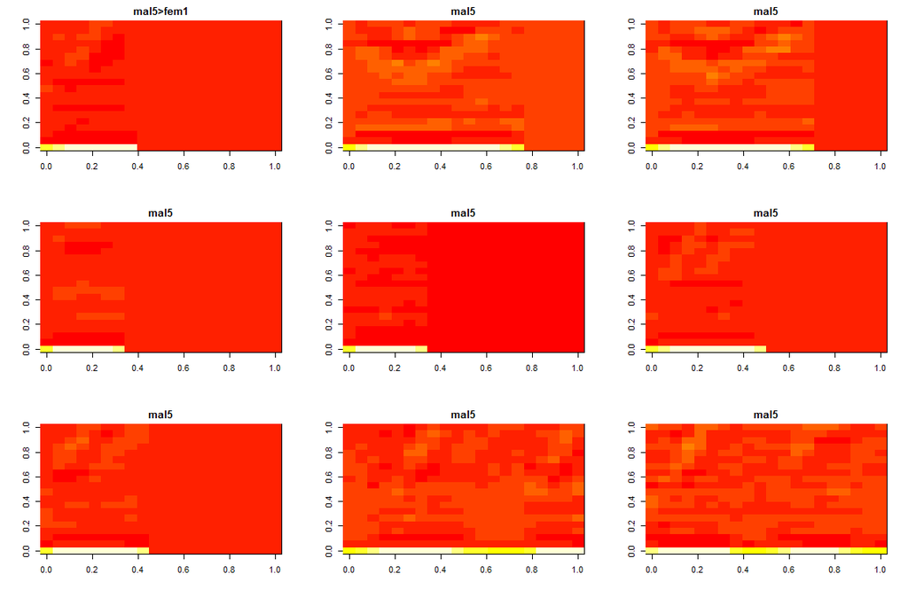

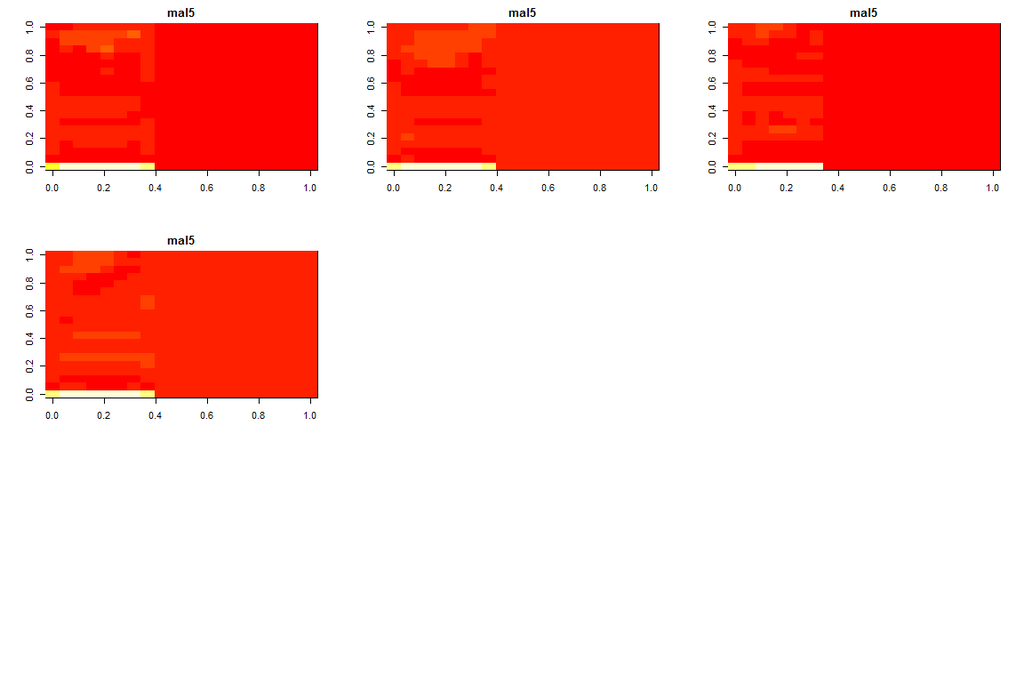

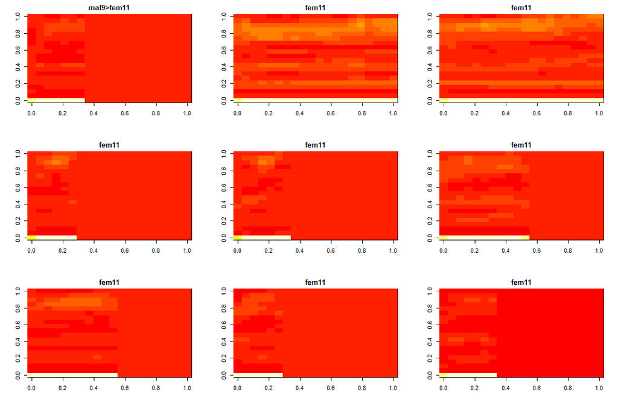

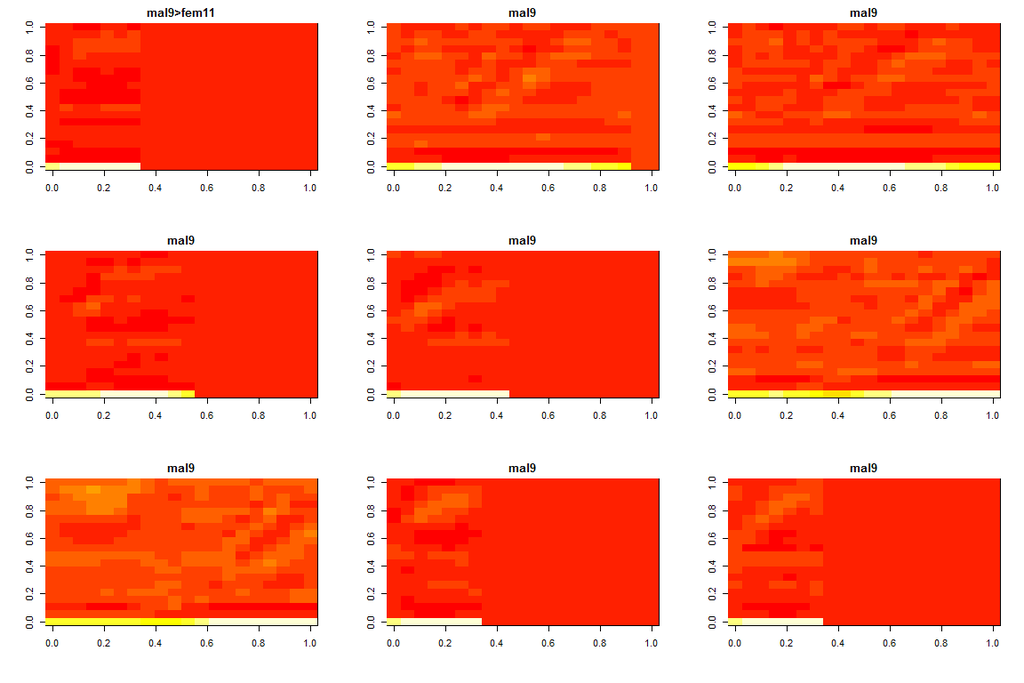

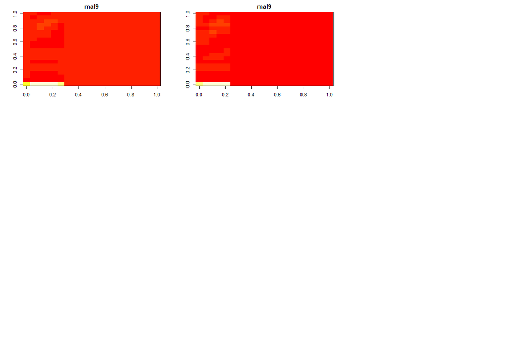

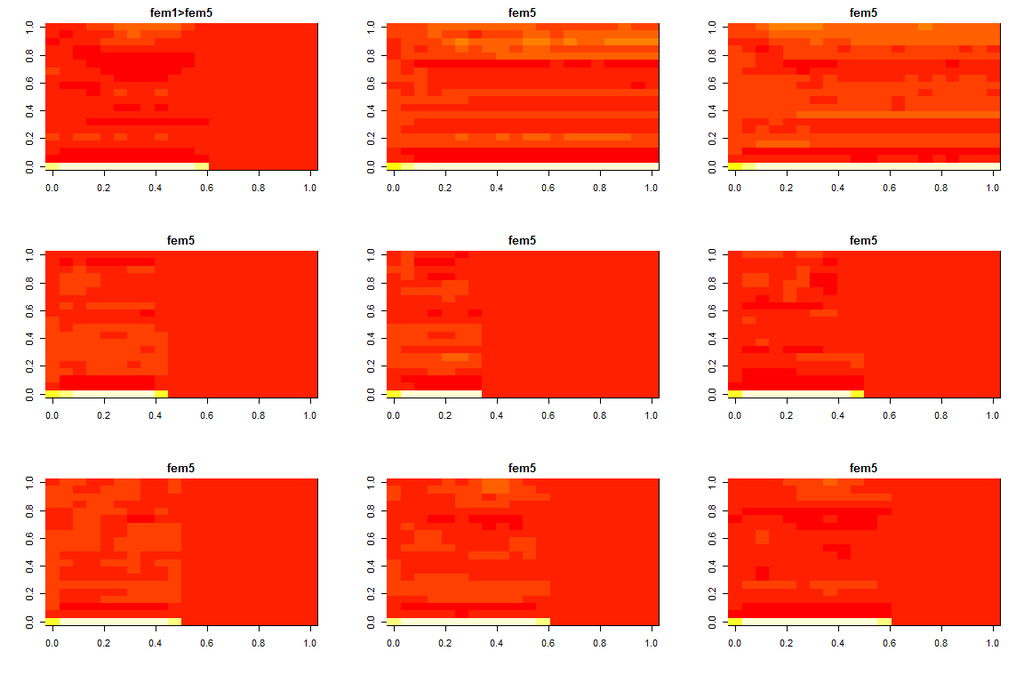

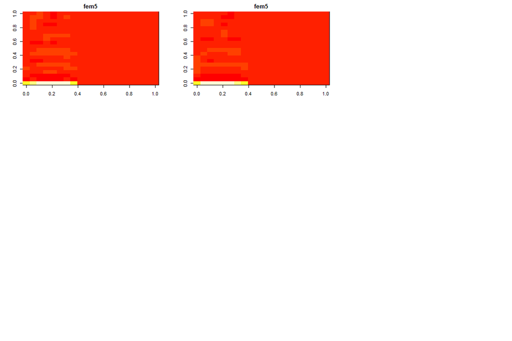

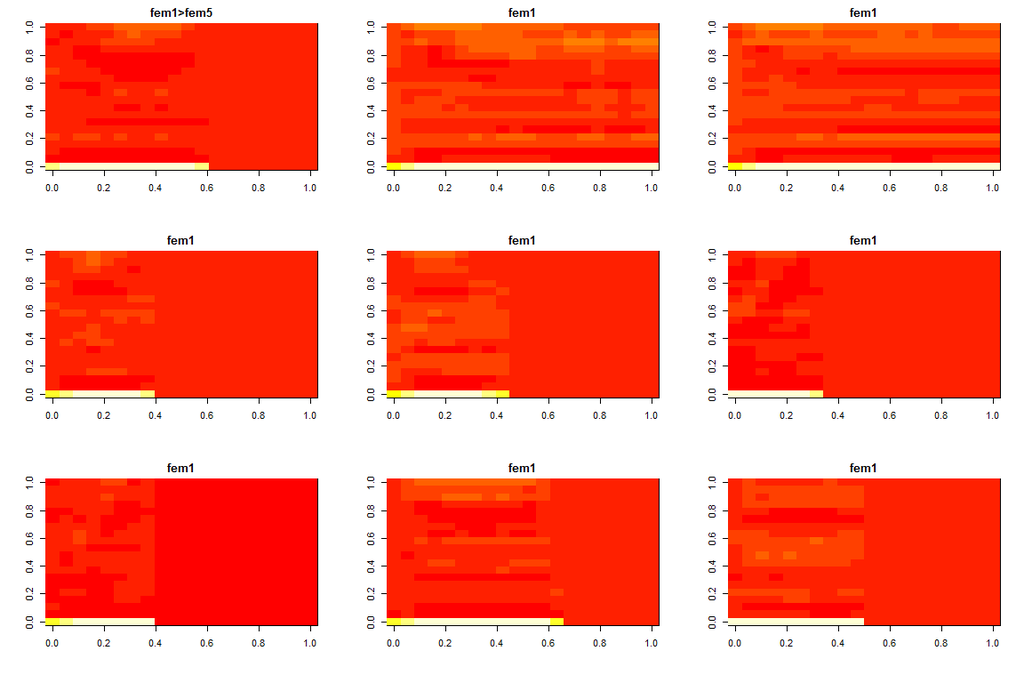

[20 more figures not shown]

```r
fn <- rf$test$predicted != test$birdid
for (i in 1:length(test$birdid)) {
  if (fn[i]) { # If it is false negative
    par(mfrow=c(3,3))
    image(t(matrix(unlist(testMels_20[i,]),ncol = 20, byrow = TRUE)))
    title(paste0(rf$test$predicted[i],">",test$birdid[i]))
    # Show ground truth bird's spectrograms in train dataset
    groundTBird <- which(train$birdid==test$birdid[i])
    for (id in groundTBird) {
      image(t(matrix(unlist(trainMels_20[id,]),ncol = 20, byrow = TRUE)))
      title(test$birdid[i])
    }

    par(mfrow=c(3,3))
    image(t(matrix(unlist(testMels_20[i,]),ncol = 20, byrow = TRUE)))
    title(paste0(rf$test$predicted[i],">",test$birdid[i]))
    # Show falsely predicted bird's spectrograms in train dataset
    predBird <- which(train$birdid==rf$test$predicted[i])
    for (id in predBird) {
      image(t(matrix(unlist(trainMels_20[id,]),ncol = 20, byrow = TRUE)))
      title(rf$test$predicted[i])
    }
  }
}
```